# Using Keras to Build and Train Recurrent Neural Networks

Currently, our data is in the form: [samples, features] and we are framing the problem as one time step for each sample. We can transform the prepared train and test input data into the expected structure using np.reshape().

```python
# Complete: reshape the trian input (trainX) to be [samples, time steps, features]

trainX = np.reshape(trainX,(trainX.shape[0],1, trainX.shape[1]) )
# Complete: reshape the test input (testX) to be [samples, time steps, features]
testX = np.reshape(testX,(testX.shape[0],1, testX.shape[1]) )
```

We are now ready to design our LSTM network for this problem.

Next complile and fit the model. The network is trained for 100 epochs and a batch size of 1 is used.

```python
# build the model
model = Sequential()

model.add(LSTM(4, input_shape=(1, look_back)))

model.add(Dense(1))

#compile and train the model
model.compile(loss='mean_squared_error', optimizer='adam')
model.fit(trainX, trainY, epochs=100, batch_size=1, verbose=2)
```

[output not shown]

[output cut: 51 more lines]

[output not shown]

```
<keras.callbacks.History at 0x15d8f965e10>
```

```python
#look at the summary our model
model.summary()
```

[output not shown]

Once the model is fit, we can estimate the performance of the model on the train and test datasets. This will give us a point of comparison for new models.

Note that we invert the predictions before calculating error scores to ensure that performance is reported in the same units as the original data (thousands of passengers per month).

```python
# make predictions
trainPredict = model.predict(trainX)
testPredict = model.predict(testX)
# invert predictions
trainPredict = scaler.inverse_transform(trainPredict)
trainY = scaler.inverse_transform([trainY])
testPredict = scaler.inverse_transform(testPredict)
testY = scaler.inverse_transform([testY])
# calculate root mean squared error
trainScore = math.sqrt(mean_squared_error(trainY[0], trainPredict[:,0]))
print('Train Score: %.2f RMSE' % (trainScore))
testScore = math.sqrt(mean_squared_error(testY[0], testPredict[:,0]))
print('Test Score: %.2f RMSE' % (testScore))
```

```
Train Score: 22.92 RMSE
Test Score: 47.53 RMSE
```

Finally, we can generate predictions using the model for both the train and test dataset to get a visual indication of the skill of the model.

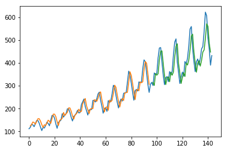

```python
#create a carcass or a container that looks like our original data
trainPredictPlot = np.empty_like(dataset)
trainPredictPlot[:, :] = np.nan# fill nan (could be zeros)


#fit the data in the trainPredictPlot container we just create
trainPredictPlot[look_back:len(trainPredict)+look_back, :] = trainPredict
# shift test predictions for plotting
testPredictPlot = np.empty_like(dataset)
testPredictPlot[:, :] = np.nan
testPredictPlot[len(trainPredict)+(look_back*2)+1:len(dataset)-1, :] = testPredict
# plot baseline and predictions
plt.plot(scaler.inverse_transform(dataset))
plt.plot(trainPredictPlot)
plt.plot(testPredictPlot)
plt.show()
```